# Analysis of Collisions with Cyclist Participation by Regional Typology in Germany Code Documentation

This is the R Skript corresponding to the Bachelor Thesis “Analysis of Collisions with Cyclist Participation by Regional Typology in Germany” by the author Lasse Harkort. In the first section the functions for downloading and processing collision data from the collision dataset of the German Federal Statistical Office will be presented and explained step by step. The sections that follow represent the workflow for all statistics and graphs that are included in the thesis.To run the full script at once **you will need the folder with some additional data** starting from the section *“Nearest road maximum speed limit”* as some of the steps have been made in the software QGIS.

Note: The library collisionsDE is a self written library by the author

**Libraries**

```r
library("devtools")# for downloading GitHub packages
#install_github("lutzhutz/collisionsDE")
#install.packages("colorspace")
library(collisionsDE)
library(colorspace)
library(dplyr)
library(sf)
```

```r
library(ggplot2)
library(lemon)
library(tidyr)
library(stringr)
library(ggpubr)
library(grid)
```

Legend (chronologically):

- y.## = year (e.g. 2018 -> y.18)
- .df = data frame of all collisions
- .b = all collisions with at least one cyclist involved
- .f = frequency
- .k = killed
- .si = seriously injured
- .sli = slightly injured
- .sev = severity
- .ct = collision type
- .ck = collision - killed
- .c = collisions
- .m = month
- .h = hours (daytime)
- .w = weekdays
- .osm = highway data from Open Street Map
- .s = subset
- .m = maxspeed categories
- .mot = motorized
- .g = grouped
- .wi = with information (roads with information on maximum speed limit)
- .ni = no information (roads with no information on maximum speed limit)
- .mfc = merged feature classes (merged datasets of .wi and .ni)

#Pre-processing

```r
#disable e format
options(scipen = 999)

#import all reported collisions with personal injury from 2018 (function from collisionsDE)
y.18<-import_2018()

#add regional information to the collision events (function from collisionsDE)
y.18<-add_regions(y.18)

#transform from spatial feature object to data frame
y.18.df <- y.18 %>% st_drop_geometry()

#subset all accident with at least one cyclist involved
y.18.df.b <- y.18.df[y.18.df$IstRad == 1,]

#data frame overview
head(y.18.df.b)
```

```
##        gem ULAND UREGBEZ UKREIS UGEMEINDE UJAHR UMONAT USTUNDE UWOCHENTAG
## 2  1001000    01       0     01       000  2018     06      14          6
## 4  1001000    01       0     01       000  2018     05      14          3
## 6  1001000    01       0     01       000  2018     05      07          6
## 10 1001000    01       0     01       000  2018     05      20          4
## 12 1001000    01       0     01       000  2018     09      06          2
## 15 1001000    01       0     01       000  2018     06      12          5
##    UKATEGORIE UART UTYP1 ULICHTVERH IstRad IstPKW IstFuss IstKrad IstGkfz
## 2           3    5     2          0      1      0       0       0       0
## 4           3    5     2          0      1      1       0       0       0
## 6           3    5     2          0      1      1       0       0       0
## 10          3    5     3          0      1      1       0       0       0
## 12          3    7     1          2      1      0       0       0       0
## 15          3    0     1          0      1      0       0       0       0
##    IstSonstig STRZUSTAND  LINREFX LINREFY XGCSWGS84 YGCSWGS84     gemrs
```

[output cut: 27 more lines]

```r
#suppress note message from dplyr
options(dplyr.summarise.inform=F)
```

#Collision frequency

```r
# Here the values of table 2 in the thesis are created

y.18.f <-
  y.18.df %>%
  mutate(countb = if_else(y.18.df$IstRad == 1, 1, 0)) %>% #indicate all collisions where at least one cyclist has been involved
  group_by(gemname, regio7bez, gembev, gemfl) %>%
  summarise(count = sum(n()),
            countb = sum(countb)) %>% #sum up the number of all collisions, the number of collisions with cyclist participation, population and area
  group_by(regio7bez) %>% #sum these up again to the seven regional levels
  summarise(
    gsm_fl = sum(gemfl), #total area
    gsm_bev = sum(gembev), #total population
    count = sum(count), #number of collisions
    countb = sum(countb), #number of collisions with cyclist participation
    popdens = gsm_bev / gsm_fl,
    .groups = "drop" #population density
  ) %>%
  mutate(
    gsm_fl_s = gsm_fl / sum(gsm_fl) * 100,
    gsm_bev_s = gsm_bev / sum(gsm_bev) * 100,
    share_s = count / sum(count) * 100,
    shareb_s = countb / sum(countb) * 100,
    acc_pers = count * 10000 / gsm_bev,
    acc_persb = countb * 10000 / gsm_bev #calculate the shares of each of the variables calculated before as well as the collisions per 10.000 residents of each region
  )

round(y.18.f$acc_persb, 1) #round the numbers to the first decimal
```

```
## [1] 14.2 13.8  8.5  4.9 13.0  8.2  4.8
```

```r
cor.test(y.18.f$popdens, y.18.f$acc_pers, method = "pearson") #calculate correlation
```

```
##
##  Pearson's product-moment correlation
##
## data:  y.18.f$popdens and y.18.f$acc_pers
## t = 1.7972, df = 5, p-value = 0.1322
## alternative hypothesis: true correlation is not equal to 0
## 95 percent confidence interval:
##  -0.2396493  0.9373264
## sample estimates:
##       cor
## 0.6264673
```

```r
cor.test(y.18.f$popdens, y.18.f$acc_persb, method = "pearson") #calculate correlation
```

```
##
##  Pearson's product-moment correlation
##
## data:  y.18.f$popdens and y.18.f$acc_persb
## t = 2.6142, df = 5, p-value = 0.04743
## alternative hypothesis: true correlation is not equal to 0
## 95 percent confidence interval:
##  0.01606603 0.96229446
## sample estimates:
##     cor
## 0.75993
```

#Collision severity

```r
y.18.df.k <-
  y.18.df.b[y.18.df.b$UKATEGORIE == 1, ] #subset all collisions with at least one person killed

#transform data
y.18.df.k <- y.18.df.k %>%
  group_by(regio7bez) %>%
  summarise(count = n()) %>%
  mutate(share = count / sum(count) * 100,
         cat = "killed") #calculate the shares of all fatal crashes by each region

y.18.df.si <-
  y.18.df.b[y.18.df.b$UKATEGORIE == 2, ] #subset all collisions with at least one person seriously injured

#transform data
y.18.df.si <- y.18.df.si %>%
  group_by(regio7bez) %>%
  summarise(count = n()) %>%
  mutate(share = count / sum(count) * 100,
         cat = "seriously_injured") #calculate the shares of all crashes with at least one person seriously injured by each region

y.18.df.sli <-
  y.18.df.b[y.18.df.b$UKATEGORIE == 3, ] #subset all collisions with at least one person slightly injured

#transform data
y.18.df.sli <- y.18.df.sli %>%
  group_by(regio7bez) %>%
  summarise(count = n()) %>%
  mutate(share = count / sum(count) * 100,
         cat = "injury") #calculate the shares of all crashes with at least one person slightly injured by each region


y.18.df.sev <-
  rbind(y.18.df.k, y.18.df.si, y.18.df.sli) #combine the three created datasets

#check total counts
sum(y.18.df.k$count)
```

```
## [1] 306
```

```r
sum(y.18.df.si$count)
```

```
## [1] 10039
```

```r
sum(y.18.df.sli$count)
```

```
## [1] 47077
```

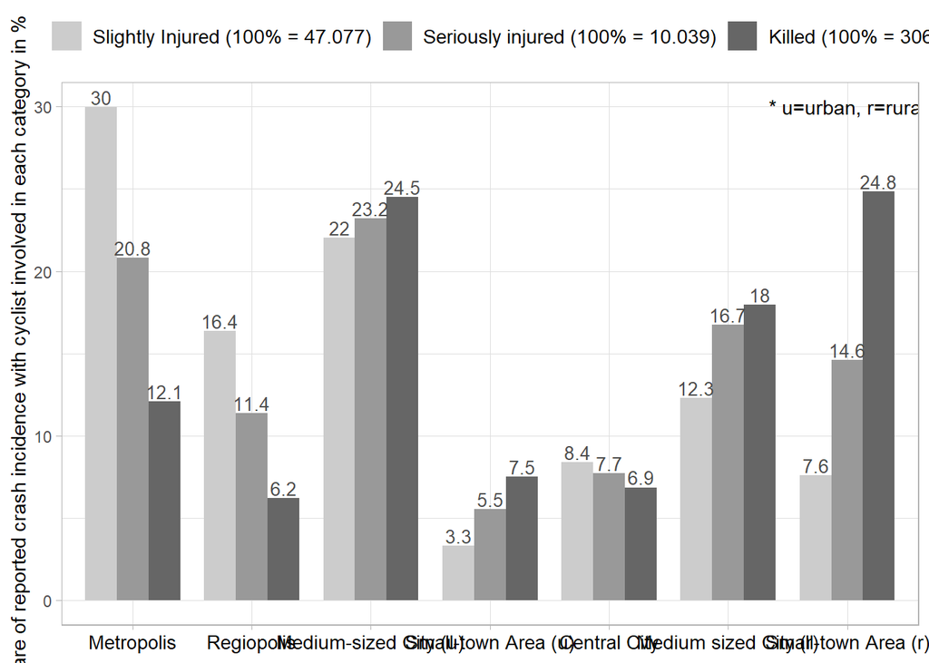

```r
#visualization (Figure 9 in Thesis)
ggplot(
  transform(
    y.18.df.sev,
    cat = factor(
      cat,
      levels =
        c("injury",
          "seriously_injured",
          "killed"),
      label = c(
        "Slightly Injured (100% = 47.077)",
        "Seriously injured (100% = 10.039)",
        "Killed (100% = 306)"
      )
    ),
    regio7bez = factor(
      regio7bez,
      levels =
        c(
          "U_Metro",
          "U_Regiop",
          "U_Medium",
          "U_Small",
          "R_C",
          "R_Med_C",
          "R_Small_C"
        ),
      label = c(
        "Metropolis",
        "Regiopolis",
        "Medium-sized City (u)",
        "Small-town Area (u)",
        "Central City",
        "Medium sized City (r)",
        "Small-town Area (r)"
      )
    )
  ),
  aes(regio7bez, share, fill = cat)
) +
  geom_bar(stat = "identity",
           position = "dodge",
           width = 0.8) +
  geom_text(
    aes(label = round(share, 1)),
    position = position_dodge(width = 0.8),
    vjust = -0.2,
    color = "gray30",
    size = 3.5
  ) +
  ylab("Share of reported crash incidence with cyclist involved in each category in %") +
  theme_light() +
  scale_fill_manual("",
                    values = c("grey80",
                               "grey60",
                               "grey40")) +
  theme(
    axis.title.x = element_blank(),
    axis.text.x = element_text(colour = "black", size = 10.5),
    legend.position = "top",
    legend.justification = "left",
    legend.text = element_text(size = 10.5)
  ) +
  annotate("text",
           label = "* u=urban, r=rural",
           x = 7,
           y = 30)
```

```r
#save in output workspace
#ggsave("severity.png",width = 11.5,height = 6.31,dpi = 300)
```

#Collision type

```r
#calculate share of each collision type by region
y.18.df.b.ct <- y.18.df.b %>%
  group_by(regio7bez, UTYP1) %>%
  summarise(count = n()) %>%
  mutate(share = count / sum(count) * 100)

#visualize (Figure 10 in thesis)
type<-ggplot(
    transform(
    y.18.df.b.ct,
    UTYP1 = factor(
      UTYP1,
      levels = c(
        "3",
        "2",
        "1",
        "7",
        "6",
        "5",
        "4"
      ),
      label = c(
        "collision when turing into/crossing",
        "collision when turning off",
        "driving collision",
        "other collision",
        "collision while moving along",
        "collision with stationary vehicle",
        "collision while pedestrian crossing"
      )
    ),
    regio7bez = factor(
      regio7bez,
      levels =
        c(
          "R_Small_C",
          "R_Med_C",
          "R_C",
          "U_Small",
          "U_Medium",
          "U_Regiop",
          "U_Metro"
        ),
      label = c(
        "Small-town Area (r)",
        "Medium sized City (r)",
        "Central City",
        "Small-town Area (u)",
        "Medium-sized City (u)",
        "Regiopolis",
        "Metropolis"
      )
    )
  ),
  aes(x = share, y = regio7bez)
) +
  facet_wrap( ~ UTYP1, ncol = 4)  +
  geom_bar(stat = "identity", fill = rep(c("#B42A5D",
    "#FE2F7C",
    "#FF7776",
    "#FFE0DC",
    "#00858B",
    "#41B8B9",
    "#D2E38C"
  ),7)) +
  geom_text(aes(label = round(share,1)), hjust = -0.08, size = 3) +
  theme_light() +
  scale_x_continuous(limits = c(0, 42)) +
  theme(
    axis.title.x = element_blank(),
    axis.title.y = element_blank(),
    axis.text.x = element_text(size = 10),
    axis.text.y = element_text(color = 'black',size = 10),
    strip.text = element_text(color = 'black',size = 10, face = "italic"),
    strip.background = element_blank()
  )

#check total counts
y.18.df.b.ct %>%
  group_by(regio7bez) %>%
  summarise(count = sum(count))
```

```
## # A tibble: 7 x 2
##   regio7bez count
##   <fct>     <int>
## 1 U_Metro   16232
## 2 U_Regiop   8870
## 3 U_Medium  12781
## 4 U_Small    2137
## 5 R_C        4754
## 6 R_Med_C    7531
## 7 R_Small_C  5117
```

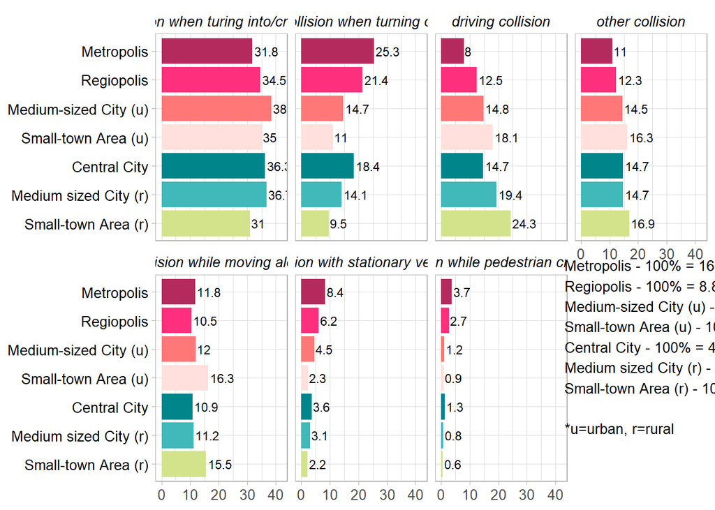

```r
#add counts to ggplot graph
print(type)
grid.text(
  paste0(
    "Metropolis - 100% = 16.232",
    "\n",
    "Regiopolis - 100% = 8.870",
    "\n",
    "Medium-sized City (u) - 100% = 12.781",
    "\n",
    "Small-town Area (u) - 100% = 2.137",
    "\n",
    "Central City - 100% = 4754",
    "\n",
    "Medium sized City (r) - 100% = 7.531",
    "\n",
    "Small-town Area (r) - 100% = 5.117",
    "\n",
    "\n",
    "*u=urban, r=rural"
  ),
  x = 0.79,
  y = 0.32,
  just = "left",
  gp = gpar(fontsize = 10)
)
```

```r
#export:Save as image .. 1122x590
```

#Collisions between cyclists and other parties with fatal outcome

```r
#subset all collisions with at least one person killed
y.18.df.b.ck <- y.18.df.b[y.18.df.b$UKATEGORIE == 1,]

#add collision type with collision_types() (function from collisionsDE)
y.18.df.b.ck <- collision_types(y.18.df.b.ck)

#group by region and collision type, compute shares
y.18.df.b.ck <- y.18.df.b.ck %>%
  group_by(regio7bez, coll_typ) %>%
  summarise(count = n()) %>%
  mutate(share = count / sum(count) * 100)

#visualize (Figure 11 in the thesis)
b <- ggplot(
  transform(
    y.18.df.b.ck,
    coll_typ = factor(
      coll_typ,
      levels = c(
        "bicyclecar",
        "bicycle",
        "bicyclefoot",
        "bicycleother",
        "bicyclemcycle",
        "bicycletruck",
        "three"
      ),
      labels = c(
        "bicycle-car",
        "bicycle only accidents",
        "bicycle-foot",
        "bicycle-other parties",
        "bicycle-motorcycle",
        "bicycle-truck",
        "more than two participants"
      )
    ),
    regio7bez = factor(
      regio7bez,
      levels =
        c(
          "R_Small_C",
          "R_Med_C",
          "R_C",
          "U_Small",
          "U_Medium",
          "U_Regiop",
          "U_Metro"
        ),
      label = c(
        "Small-town Area (r)",
        "Medium sized City (r)",
        "Central City",
        "Small-town Area (u)",
        "Medium-sized City (u)",
        "Regiopolis",
        "Metropolis"
      )
    )
  ),
  aes(x = share, y = regio7bez)
) +
  facet_wrap( ~ coll_typ, ncol = 4)  +
  geom_bar(
    stat = "identity",
    fill = c(
      "#B42A5D",
      "#FE2F7C",
      "#FF7776",
      "#FFE0DC",
      "#00858B",
      "#41B8B9",
      "#D2E38C",
      "#B42A5D",
      "#FE2F7C",
      "#FF7776",
      "#FFE0DC",
      "#00858B",
      "#41B8B9",
      "#D2E38C",
      "#B42A5D",
      "#FE2F7C",
      "#41B8B9",
      "#D2E38C",
      "#B42A5D",
      "#FE2F7C",
      "#FF7776",
      "#FFE0DC",
      "#00858B",
      "#41B8B9",
      "#D2E38C",
      "#B42A5D",
      "#FE2F7C",
      "#FF7776",
      "#00858B",
      "#D2E38C",
      "#B42A5D",
      "#FE2F7C",
      "#FF7776",
      "#FFE0DC",
      "#00858B",
      "#41B8B9",
      "#FFE0DC",
      "#D2E38C"
    )
  ) +
  geom_text(aes(label = round(share, 1)), hjust = -0.08, size = 3) +
  theme_light() +
  scale_x_continuous(limits = c(0, 76)) +
  theme(
    axis.title.x = element_blank(),
    axis.title.y = element_blank(),
    axis.text.x = element_text(size = 10),
    axis.text.y = element_text(color = 'black', size = 10),
    strip.text = element_text(color = 'black', size = 10, face = "italic"),
    strip.background = element_blank()
  )

#check total counts
y.18.df.b.ck %>%
  group_by(regio7bez) %>%
  summarise(count = sum(count))
```

```
## # A tibble: 7 x 2
##   regio7bez count
##   <fct>     <int>
## 1 U_Metro      37
## 2 U_Regiop     19
## 3 U_Medium     75
## 4 U_Small      23
## 5 R_C          21
## 6 R_Med_C      55
## 7 R_Small_C    76
```

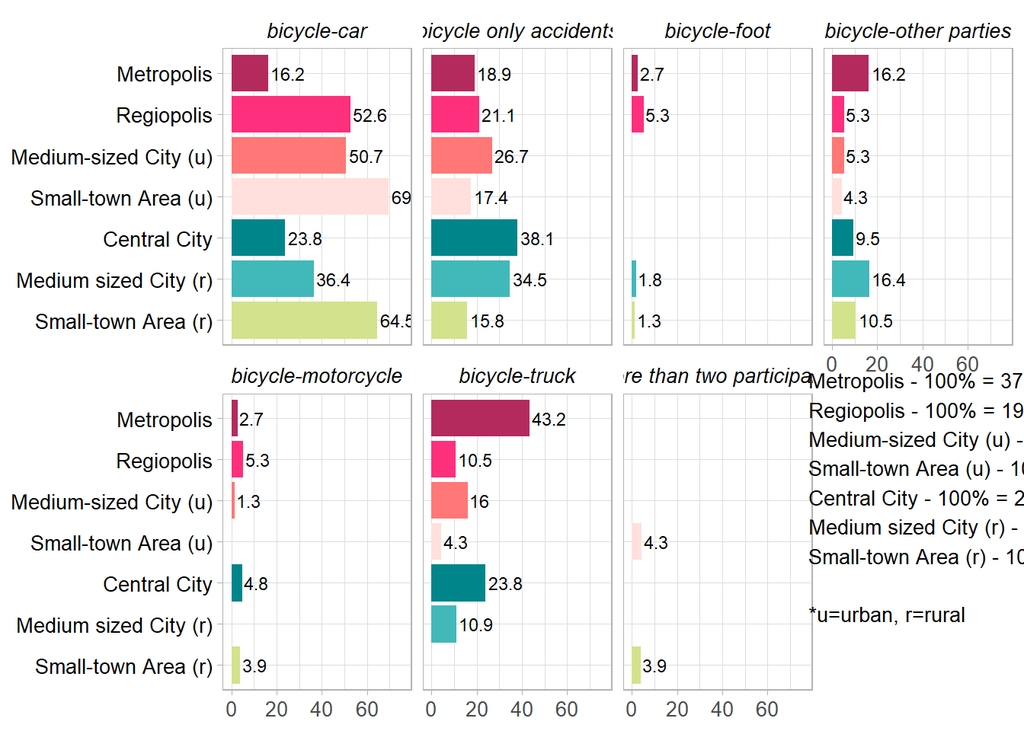

```r
#add counts to ggplot graph
print(b)
grid.text(
  paste0(
    "Metropolis - 100% = 37",
    "\n",
    "Regiopolis - 100% = 19",
    "\n",
    "Medium-sized City (u) - 100% = 75",
    "\n",
    "Small-town Area (u) - 100% = 23",
    "\n",
    "Central City - 100% = 21",
    "\n",
    "Medium sized City (r) - 100% = 55",
    "\n",
    "Small-town Area (r) - 100% = 76",
    "\n",
    "\n",
    "*u=urban, r=rural"
  ),
  x = 0.79,
  y = 0.32,
  just = "left",
  gp = gpar(fontsize = 10)
)
```

```r
#export:Save as image .. 1122x590
```

#Collisions between cyclists and other parties, all collisions

```r
#add collision type with collision_types() function by collisionsDE
y.18.df.b.c <- collision_types(y.18.df.b)

#group by region and collision type, compute shares
y.18.df.b.c <- y.18.df.b.c %>%
  group_by(regio7bez, coll_typ) %>%
  summarise(count = n()) %>%
  mutate(share = count / sum(count) * 100)

#visualize (Figure 12 in the thesis)
a <- ggplot(
  transform(
    y.18.df.b.c,
    coll_typ = factor(
      coll_typ,
      levels = c(
        "bicyclecar",
        "bicycle",
        "bicyclefoot",
        "bicycleother",
        "bicyclemcycle",
        "bicycletruck",
        "three"
      ),
      labels = c(
        "bicycle-car",
        "bicycle only accidents",
        "bicycle-foot",
        "bicycle-other parties",
        "bicycle-motorcycle",
        "bicycle-truck",
        "more than two participants"
      )
    ),
    regio7bez = factor(
      regio7bez,
      levels =
        c(
          "R_Small_C",
          "R_Med_C",
          "R_C",
          "U_Small",
          "U_Medium",
          "U_Regiop",
          "U_Metro"
        ),
      label = c(
        "Small-town Area (r)",
        "Medium sized City (r)",
        "Central City",
        "Small-town Area (u)",
        "Medium-sized City (u)",
        "Regiopolis",
        "Metropolis"
      )
    )
  ),
  aes(x = share, y = regio7bez)
) +
  facet_wrap(~ coll_typ, ncol = 4)  +
  geom_bar(stat = "identity", fill = rep(
    c(
      "#B42A5D",
      "#FE2F7C",
      "#FF7776",
      "#FFE0DC",
      "#00858B",
      "#41B8B9",
      "#D2E38C"
    ),
    7
  )) +
  geom_text(aes(label = round(share, 1)), hjust = -0.08, size = 3) +
  theme_light() +
  scale_x_continuous(limits = c(0, 70)) +
  theme(
    axis.title.x = element_blank(),
    axis.title.y = element_blank(),
    axis.text.x = element_text(size = 10),
    axis.text.y = element_text(color = 'black', size = 10),
    strip.text = element_text(color = 'black', size = 10, face = "italic"),
    strip.background = element_blank()
  )

#check total counts
y.18.df.b.c %>%
  group_by(regio7bez) %>%
  summarise(count = sum(count))
```

```
## # A tibble: 7 x 2
##   regio7bez count
##   <fct>     <int>
## 1 U_Metro   16232
## 2 U_Regiop   8870
## 3 U_Medium  12781
## 4 U_Small    2137
## 5 R_C        4754
## 6 R_Med_C    7531
## 7 R_Small_C  5117
```

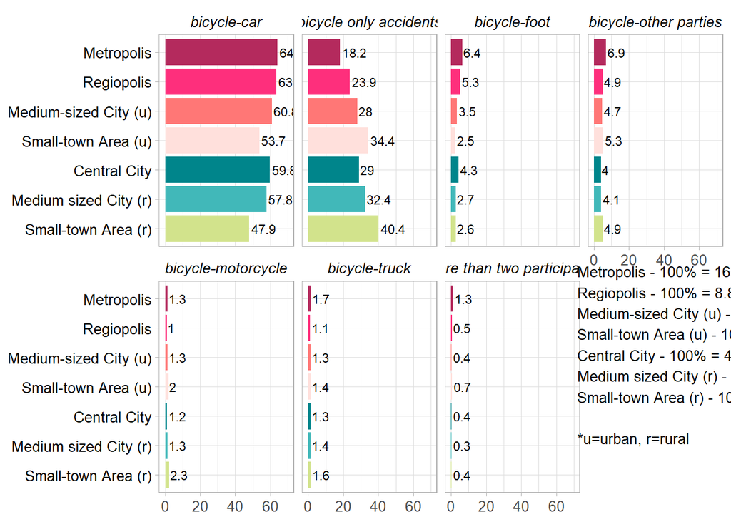

```r
#add counts to ggplot graph
print(a)
grid.text(
  paste0(
    "Metropolis - 100% = 16.232",
    "\n",
    "Regiopolis - 100% = 8.870",
    "\n",
    "Medium-sized City (u) - 100% = 12.781",
    "\n",
    "Small-town Area (u) - 100% = 2.137",
    "\n",
    "Central City - 100% = 4754",
    "\n",
    "Medium sized City (r) - 100% = 7.531",
    "\n",
    "Small-town Area (r) - 100% = 5.117",
    "\n",
    "\n",
    "*u=urban, r=rural"
  ),
  x = 0.79,
  y = 0.32,
  just = "left",
  gp = gpar(fontsize = 10)
)
```